# HW2

#### 107000105 楊晶宇

## Question 1

# Implementation

## 1.引用函式庫

```python
import numpy as np
import pandas as pd
import math
from numpy.random import seed
import matplotlib.pyplot as plt
```

## 2.資料處理

- 先把資料的column名稱替換
- 印出data的shape
- 觀察資料形式
- 宣告dictionary方便後方code易讀

```python
feature_dic = {0:'sepal length', 1:'sepal width', 2:'petal length', 3:'petal width'}
class_dic = {0:'Iris-setosa', 1:'Iris-versicolor', 2:'Iris-virginica'}
df = pd.read_csv('https://archive.ics.uci.edu/ml/'
        'machine-learning-databases/iris/iris.data', header=None)
print(df.shape)
df.columns = ['sepal length', 'sepal width', 'petal length', 'petal width', 'class']
df.tail(10)
```

```
(150, 5)
```

|  | sepal length | sepal width | petal length | petal width | class |
| --- | --- | --- | --- | --- | --- |
| 140 | 6.7 | 3.1 | 5.6 | 2.4 | Iris-virginica |
| 141 | 6.9 | 3.1 | 5.1 | 2.3 | Iris-virginica |
| 142 | 5.8 | 2.7 | 5.1 | 1.9 | Iris-virginica |
| 143 | 6.8 | 3.2 | 5.9 | 2.3 | Iris-virginica |
| 144 | 6.7 | 3.3 | 5.7 | 2.5 | Iris-virginica |
| 145 | 6.7 | 3.0 | 5.2 | 2.3 | Iris-virginica |
| 146 | 6.3 | 2.5 | 5.0 | 1.9 | Iris-virginica |
| 147 | 6.5 | 3.0 | 5.2 | 2.0 | Iris-virginica |
| 148 | 6.2 | 3.4 | 5.4 | 2.3 | Iris-virginica |
| 149 | 5.9 | 3.0 | 5.1 | 1.8 | Iris-virginica |

為了解種類的分布狀況，把三種花的資料分開來存進list，觀察shape，確定資料分布狀況平均與否：

```python
classdata_list = []
for i in range(3):
    classdata_list.append(df.loc[df['class'] == class_dic[i]])
for i in classdata_list:
    print (i.shape)
```

```
(50, 5)
(50, 5)
(50, 5)
```

資料分布平均，不會有data imbalance的問題

### 定義繪圖函式

定義一個繪圖函式，可以畫出2個feature對應3種class的圖形(用上次作業做調整)

```python
def Plot(f, df): # c is class number list, f is feature number list, df is dataframe in
    X = []
    Y = []
    for i in range(3):
        X.append(df.loc[df['class']== class_dic[i], feature_dic[f[0]]])
        Y.append(df.loc[df['class']== class_dic[i], feature_dic[f[1]]])
    plt.scatter(X[0], Y[0],
                color='red',
                marker='o',
                label=class_dic[0]) # if c[0] = 0, lebel = 'Setosa'
    plt.scatter(X[1], Y[1],
                color='blue',
                marker='o',
                label=class_dic[1])
    plt.scatter(X[2], Y[2],
                color='black',
                marker='o',
                label=class_dic[2])
    plt.xlabel(feature_dic[f[0]] + ' [cm]') # if f[0] = 0, xlebel is 'sepal lenth'
    plt.ylabel(feature_dic[f[1]] + ' [cm]')
    plt.legend(loc='upper left')
    plt.show()
```

用for迴圈把所有組合的圖都跑一遍(共6種)

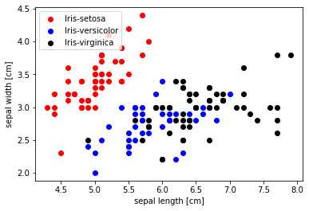

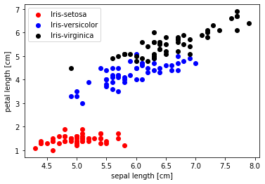

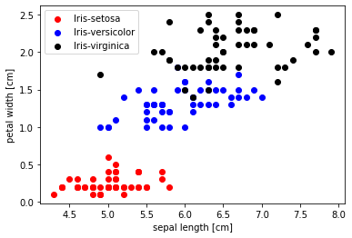

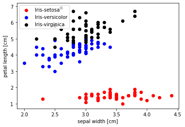

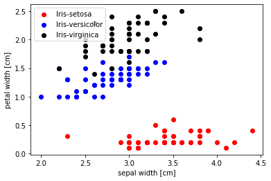

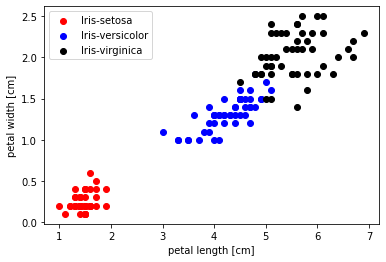

```python
for i in range(4):
    j = i + 1
    for k in range(3):
        if j >= 4:
            break
        Plot([i, j], df)
        j = j + 1
```

### 定義標準化函式

```python
def Std(X, nf):
    X_std = np.copy(X)
    for i in range(nf):
        X_std[:, i] = (X_std[:, i] - X[:, i].mean())/ X_std[:, i].std()
    return X_std
```

### 分類訓練集、測試集

- 這步順序應該在觀測資料前，但影響應該不大
- 每一類取15筆測試集，35筆訓練集(比例約3 : 7)
- 將所有數據標準化
- 特徵取 sepal length 和 sepal width

```python
feature_dic = {0:'sepal length', 1:'sepal width', 2:'petal length', 3:'petal width'}
class_dic = {0:'Iris-setosa', 1:'Iris-versicolor', 2:'Iris-virginica'}
X_train_list = []
Y_train_list = []
X_test_list = []
Y_test_list = []
j = 0

for i in classdata_list:
    X_train_list.append(i.iloc[15:, [0, 1]].values)
    Y_train_list.append(np.full(35, j))
    X_test_list.append(i.iloc[:15, [0, 1]].values)
    Y_test_list.append(np.full(15,j))
    j = j + 1

X_train_list = np.vstack(X_train_list)
X_test_list = np.vstack(X_test_list)
Y_train_list = np.hstack(Y_train_list)
Y_test_list = np.hstack(Y_test_list)
X_train_list = Std(X_train_list, 2)
X_test_list = Std(X_test_list, 2)
```

## 2.定義演算法函式(Perceptron、Adaline、AdalineSGD)

### (1) Perceptron

> eta: learning rate，預設0.01  
> n_inter: epoch number  
> random_state: 隨機變數的因子  
> fit(): training model, 隨機產生一組weight，把input丟進去train n_iter次，update參數  
> net_input(): 根據input X陣列，算矩陣dot的結果(一個常數, wx)  
> predict(): 根據netinput出來的值(是否大於0，treshhold function)，output 1 or -1(1為true)  
> errors: 紀錄每次跑完的error

```python
class Perceptron(object):
    def __init__(self, eta=0.01, n_iter=10, random_state=1):
        self.eta = eta
        self.n_iter = n_iter
        self.random_state = random_state

    def fit(self, X, y):
        rgen = np.random.RandomState(self.random_state)
        self.w_ = rgen.normal(loc=0.0, scale=0.01, size=1 + X.shape[1])
        self.errors_ = []
        for _ in range(self.n_iter):
            errors = 0
            for xi, target in zip(X, y):
                update = self.eta * (target - self.predict(xi))
                self.w_[1:] += update * xi
                self.w_[0] += update
                errors += int(update != 0.0)
            self.errors_.append(errors)
        return self

    def net_input(self, X):
        return np.dot(X, self.w_[1:]) + self.w_[0]

    def predict(self, X):
        return np.where(self.net_input(X) >= 0.0, 1, -1)
```

### (2) Adaline

> 和Perceptron大部分都一樣，主要不一樣在fit的過程  
> w的變量會根據 training rate 跟 errors決定，learning rate tune得不要太大會慢慢收斂  
> cost_是拿來紀錄每次跑完一個epoch的cost

```python
class Adaline(object):
    def __init__(self, eta=0.01, n_iter=50, random_state=1):
        self.eta = eta
        self.n_iter = n_iter
        self.random_state = random_state

    def fit(self, X, y):
        rgen = np.random.RandomState(self.random_state)
        self.w_ = rgen.normal(loc=0.0, scale=0.01, size=1 + X.shape[1])
        self.cost_ = []

        for i in range(self.n_iter):
            output = self.activation(X)
            errors = (y - output)
            self.w_[1:] += self.eta * X.T.dot(errors)
            self.w_[0] += self.eta * errors.sum()
            cost = (errors**2).sum() / 2.0
            self.cost_.append(cost)
        return self

    def net_input(self, X):
        return np.dot(X, self.w_[1:]) + self.w_[0]

    def activation(self, X):
        return self.net_input(X)

    def predict(self, X):
        return np.where(self.activation(X) >= 0.0, 1, -1)
```

### (3) AdalineSGD

> _update_weights(): 拉出來定義，會吐一個cost給fit()紀錄 fit():初始化w(用_intialize_weights，small number)，資料是一筆一筆送進去update(用zip那一行)，速度快  
> partial_fit(): fit data但是用tune過的參數，可以在之後送新的data的時候繼續train

```python
class AdalineSGD(object):
    def __init__(self, eta=0.01, n_iter=50, shuffle=True, random_state=1):
        self.eta = eta
        self.n_iter = n_iter
        self.w_initialized = False
        self.shuffle = shuffle
        if random_state:
            seed(random_state)

    def fit(self, X, y):
        self._initialize_weights(X.shape[1])
        self.cost_ = []
        for i in range(self.n_iter):
            if self.shuffle:
                X, y = self._shuffle(X, y)
            cost = []
            for xi, target in zip(X, y):
                cost.append(self._update_weights(xi, target))
            avg_cost = sum(cost) / len(y)
            self.cost_.append(avg_cost)
        return self

    def _shuffle(self, X, y):
        r = np.random.permutation(len(y))
        return X[r], y[r]

    def _initialize_weights(self, m):
        self.w_ = np.random.normal(loc=0.0, scale=0.01, size=1 + m)
        self.w_initialized = True

    def _update_weights(self, xi, target):
        output = self.activation(xi)
        error = (target - output)
        self.w_[1:] += self.eta * xi.dot(error)
        self.w_[0] += self.eta * error
        cost = 0.5 * error**2
        return cost

    def net_input(self, X):
        return np.dot(X, self.w_[1:]) + self.w_[0]

    def activation(self, X):
        return self.net_input(X)

    def predict(self, X):
        return np.where(self.activation(X) >= 0.0, 1, -1)

    def partial_fit(self, X, y):
        if not self.w_initialized:
            self._initialize_weights(X.shape[1])
        if y.ravel().shape[0] > 1:
            for xi, target in zip(X, y):
                self._update_weights(xi, target)
        else:
            self._update_weights(X, y)
        return self
```

### 定義OvR分類器物件

為了讓code簡潔，特別在寫一個物件去執行OvR：

- init : 宣告時輸入eta, n_iter, 作為內部每個分類器的參數

  ```
     n_class是class的種類
     algo是要選用的演算法，用eval函式可以根據這個字串產生不同的module
     宣告一個list去存n_class個module
  ```

- fit : 輸入訓練集，一次訓練3個module
- predict : 輸入測試集，比較每一個model都出的net_input大小，選擇較大的分類器輸出預測，並輸出list

```python
class OvR(object):
    def __init__(self, eta=0.01, n_iter=10, n_class = 3, algo = 'Perceptron', random_state=1):
        self.eta = eta
        self.n_iter = n_iter
        self.random_state = random_state
        self.n_class = n_class
        self.ppn_list = []
        for i in range(n_class):
            self.ppn_list.append(eval(algo + "(eta = self.eta, n_iter = self.n_iter)"))

    def fit(self, X, Y):
        j = 0
        for i in self.ppn_list:
            y = np.where(Y == j, 1, -1)
            i.fit(X , y)
            j += 1

    def predict(self, X):
        z_list = []
        y_list = []
        for i in self.ppn_list:
            z_list.append(i.net_input(X))
        z = np.dstack(z_list)
        z = np.reshape(z, (len(X), self.n_class))
        for l in z:
            l = l.tolist()
            y_list.append(l.index(max(l)))
        return y_list
```

### 定義準確率函式

```python
def ACC(pre, test):
    a = zip(pre, test)
    hit = 0
    for i in a:
        if i[0] == i[1]:
            hit += 1
    return hit / len(pre)
```

## Result

### (1) Perceptron

### 輸出的兩行字串：第一行是taget，第二行是predict

```python
mppn = OvR(eta = 0.001, n_iter=100, algo = 'Perceptron')
mppn.fit(X_train_list, Y_train_list)
pre_list = mppn.predict(X_test_list)
print(Y_test_list.tolist())
print(pre_list)
print('acc = ', ACC(pre_list, Y_test_list.tolist()))
```

```
[0, 0, 0, 0, 0, 0, 0, 0, 0, 0, 0, 0, 0, 0, 0, 1, 1, 1, 1, 1, 1, 1, 1, 1, 1, 1, 1, 1, 1, 1, 2, 2, 2, 2, 2, 2, 2, 2, 2, 2, 2, 2, 2, 2, 2]
[0, 0, 0, 0, 0, 0, 0, 0, 0, 0, 0, 0, 0, 0, 0, 2, 2, 2, 2, 2, 2, 2, 1, 2, 1, 1, 2, 2, 2, 2, 2, 2, 2, 2, 2, 2, 1, 2, 2, 2, 2, 2, 2, 2, 2]
acc =  0.7111111111111111
```

### (2) Adaline

```python
mada = OvR(eta = 0.001, n_iter=100, algo = 'Adaline')
mada.fit(X_train_list, Y_train_list)
pre_list = mada.predict(X_test_list)
print(Y_test_list.tolist())
print(pre_list)
print('acc = ', ACC(pre_list, Y_test_list.tolist()))
```

```
[0, 0, 0, 0, 0, 0, 0, 0, 0, 0, 0, 0, 0, 0, 0, 1, 1, 1, 1, 1, 1, 1, 1, 1, 1, 1, 1, 1, 1, 1, 2, 2, 2, 2, 2, 2, 2, 2, 2, 2, 2, 2, 2, 2, 2]
[0, 0, 0, 0, 0, 0, 0, 0, 0, 0, 0, 0, 0, 0, 0, 2, 2, 2, 1, 2, 1, 2, 1, 2, 1, 1, 2, 1, 2, 1, 2, 1, 2, 2, 2, 2, 1, 2, 2, 2, 2, 2, 2, 1, 1]
acc =  0.7333333333333333
```

### (3)AdalineSGD

```python
mada = OvR(eta = 0.001, n_iter=50, algo = 'AdalineSGD')
mada.fit(X_train_list, Y_train_list)
pre_list = mada.predict(X_test_list)
print(Y_test_list.tolist())
print(pre_list)
print('acc = ', ACC(pre_list, Y_test_list.tolist()))
```

```
[0, 0, 0, 0, 0, 0, 0, 0, 0, 0, 0, 0, 0, 0, 0, 1, 1, 1, 1, 1, 1, 1, 1, 1, 1, 1, 1, 1, 1, 1, 2, 2, 2, 2, 2, 2, 2, 2, 2, 2, 2, 2, 2, 2, 2]
[0, 0, 0, 0, 0, 0, 0, 0, 0, 0, 0, 0, 0, 0, 0, 2, 2, 2, 1, 2, 1, 2, 1, 2, 1, 1, 2, 1, 2, 1, 2, 1, 2, 2, 2, 2, 1, 2, 2, 2, 2, 2, 2, 1, 1]
acc =  0.7333333333333333
```

### 最高準確率：73.3%

## Discussion

> 1.關於**特徵**的選擇：一開始我選petal width 跟 petal length，結果不太好。  
> 經過分析後，我發現不能選正相關或負相關性太高的特徵做分析，原因是這些都是線性分類器  
> 如果選擇**相關係數太高**的特徵切，介於中間的類別那條train出來的線會很差，看下圖，如果今天  
> 要我們選擇一條線**切開藍色與非藍色的點**，無論我們怎麼畫都很難畫好，雖然紅色很好畫出紅與非紅  
> 的分界線，但是**在OvR中擔任分辨藍與非藍的分類器就會表現很差**，造成只要是藍色類別的都有高機率被預測錯

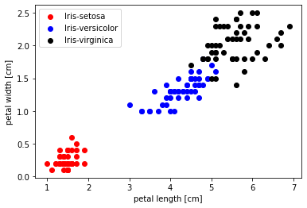

```python
Plot([2, 3], df)
```

> 因此，要選擇看不太出相關性，但是在圖上又有明顯區塊的特徵(三個區域並**非排一直線，而是呈現三角形**)  
> 來training，才能畫出三條線把彼此分開，因此我選擇sepal width跟 sepal length(如下圖)

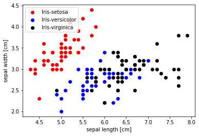

```python
Plot([0, 1], df)
```

> 2.關於參數的tuning: 由於這筆測資很小，因此我最後選擇設定很小的lr rate跟很大的n_iter  
> 讓參數慢慢更新很多次確保準確率。一開始有試過把learning rate調大到0.5  
> 但是好像太大了，Adaline直接壞掉，準確率變20%，也有比較過SGD跟沒有SGD  
> 把n_iter調小，SGD的準確率比較高，比較快到低處。

## Question 2

# implement

## 1.資料處理

先觀察資料格式和shape，發現column名稱是亂碼

```python
df = pd.read_csv('https://archive.ics.uci.edu/ml/machine-learning-databases/wine/wine.data')
print(df.shape)
df.head(10)
```

```
(177, 14)
```

|  | 1 | 14.23 | 1.71 | 2.43 | 15.6 | 127 | 2.8 | 3.06 | .28 | 2.29 | 5.64 | 1.04 | 3.92 | 1065 |
| --- | --- | --- | --- | --- | --- | --- | --- | --- | --- | --- | --- | --- | --- | --- |
| 0 | 1 | 13.20 | 1.78 | 2.14 | 11.2 | 100 | 2.65 | 2.76 | 0.26 | 1.28 | 4.38 | 1.05 | 3.40 | 1050 |
| 1 | 1 | 13.16 | 2.36 | 2.67 | 18.6 | 101 | 2.80 | 3.24 | 0.30 | 2.81 | 5.68 | 1.03 | 3.17 | 1185 |
| 2 | 1 | 14.37 | 1.95 | 2.50 | 16.8 | 113 | 3.85 | 3.49 | 0.24 | 2.18 | 7.80 | 0.86 | 3.45 | 1480 |
| 3 | 1 | 13.24 | 2.59 | 2.87 | 21.0 | 118 | 2.80 | 2.69 | 0.39 | 1.82 | 4.32 | 1.04 | 2.93 | 735 |
| 4 | 1 | 14.20 | 1.76 | 2.45 | 15.2 | 112 | 3.27 | 3.39 | 0.34 | 1.97 | 6.75 | 1.05 | 2.85 | 1450 |
| 5 | 1 | 14.39 | 1.87 | 2.45 | 14.6 | 96 | 2.50 | 2.52 | 0.30 | 1.98 | 5.25 | 1.02 | 3.58 | 1290 |
| 6 | 1 | 14.06 | 2.15 | 2.61 | 17.6 | 121 | 2.60 | 2.51 | 0.31 | 1.25 | 5.05 | 1.06 | 3.58 | 1295 |
| 7 | 1 | 14.83 | 1.64 | 2.17 | 14.0 | 97 | 2.80 | 2.98 | 0.29 | 1.98 | 5.20 | 1.08 | 2.85 | 1045 |
| 8 | 1 | 13.86 | 1.35 | 2.27 | 16.0 | 98 | 2.98 | 3.15 | 0.22 | 1.85 | 7.22 | 1.01 | 3.55 | 1045 |
| 9 | 1 | 14.10 | 2.16 | 2.30 | 18.0 | 105 | 2.95 | 3.32 | 0.22 | 2.38 | 5.75 | 1.25 | 3.17 | 1510 |

重新給colums名稱，特徵直接用1~13編號

```python
df.columns = ['class', '1', '2', '3', '4', '5',
                    '6', '7', '8',  '9', '10', '11', '12', '13']
df.tail(10)
```

|  | class | 1 | 2 | 3 | 4 | 5 | 6 | 7 | 8 | 9 | 10 | 11 | 12 | 13 |
| --- | --- | --- | --- | --- | --- | --- | --- | --- | --- | --- | --- | --- | --- | --- |
| 167 | 3 | 13.58 | 2.58 | 2.69 | 24.5 | 105 | 1.55 | 0.84 | 0.39 | 1.54 | 8.660000 | 0.74 | 1.80 | 750 |
| 168 | 3 | 13.40 | 4.60 | 2.86 | 25.0 | 112 | 1.98 | 0.96 | 0.27 | 1.11 | 8.500000 | 0.67 | 1.92 | 630 |
| 169 | 3 | 12.20 | 3.03 | 2.32 | 19.0 | 96 | 1.25 | 0.49 | 0.40 | 0.73 | 5.500000 | 0.66 | 1.83 | 510 |
| 170 | 3 | 12.77 | 2.39 | 2.28 | 19.5 | 86 | 1.39 | 0.51 | 0.48 | 0.64 | 9.899999 | 0.57 | 1.63 | 470 |
| 171 | 3 | 14.16 | 2.51 | 2.48 | 20.0 | 91 | 1.68 | 0.70 | 0.44 | 1.24 | 9.700000 | 0.62 | 1.71 | 660 |
| 172 | 3 | 13.71 | 5.65 | 2.45 | 20.5 | 95 | 1.68 | 0.61 | 0.52 | 1.06 | 7.700000 | 0.64 | 1.74 | 740 |
| 173 | 3 | 13.40 | 3.91 | 2.48 | 23.0 | 102 | 1.80 | 0.75 | 0.43 | 1.41 | 7.300000 | 0.70 | 1.56 | 750 |
| 174 | 3 | 13.27 | 4.28 | 2.26 | 20.0 | 120 | 1.59 | 0.69 | 0.43 | 1.35 | 10.200000 | 0.59 | 1.56 | 835 |
| 175 | 3 | 13.17 | 2.59 | 2.37 | 20.0 | 120 | 1.65 | 0.68 | 0.53 | 1.46 | 9.300000 | 0.60 | 1.62 | 840 |
| 176 | 3 | 14.13 | 4.10 | 2.74 | 24.5 | 96 | 2.05 | 0.76 | 0.56 | 1.35 | 9.200000 | 0.61 | 1.60 | 560 |

看一下資料的狀況

```python
df.describe()
```

|  | class | 1 | 2 | 3 | 4 | 5 | 6 | 7 | 8 | 9 | 10 | 11 | 12 | 13 |
| --- | --- | --- | --- | --- | --- | --- | --- | --- | --- | --- | --- | --- | --- | --- |
| count | 177.000000 | 177.000000 | 177.000000 | 177.000000 | 177.000000 | 177.000000 | 177.000000 | 177.000000 | 177.000000 | 177.000000 | 177.000000 | 177.000000 | 177.000000 | 177.000000 |
| mean | 1.943503 | 12.993672 | 2.339887 | 2.366158 | 19.516949 | 99.587571 | 2.292260 | 2.023446 | 0.362316 | 1.586949 | 5.054802 | 0.956983 | 2.604294 | 745.096045 |
| std | 0.773991 | 0.808808 | 1.119314 | 0.275080 | 3.336071 | 14.174018 | 0.626465 | 0.998658 | 0.124653 | 0.571545 | 2.324446 | 0.229135 | 0.705103 | 314.884046 |
| min | 1.000000 | 11.030000 | 0.740000 | 1.360000 | 10.600000 | 70.000000 | 0.980000 | 0.340000 | 0.130000 | 0.410000 | 1.280000 | 0.480000 | 1.270000 | 278.000000 |
| 25% | 1.000000 | 12.360000 | 1.600000 | 2.210000 | 17.200000 | 88.000000 | 1.740000 | 1.200000 | 0.270000 | 1.250000 | 3.210000 | 0.780000 | 1.930000 | 500.000000 |
| 50% | 2.000000 | 13.050000 | 1.870000 | 2.360000 | 19.500000 | 98.000000 | 2.350000 | 2.130000 | 0.340000 | 1.550000 | 4.680000 | 0.960000 | 2.780000 | 672.000000 |
| 75% | 3.000000 | 13.670000 | 3.100000 | 2.560000 | 21.500000 | 107.000000 | 2.800000 | 2.860000 | 0.440000 | 1.950000 | 6.200000 | 1.120000 | 3.170000 | 985.000000 |
| max | 3.000000 | 14.830000 | 5.800000 | 3.230000 | 30.000000 | 162.000000 | 3.880000 | 5.080000 | 0.660000 | 3.580000 | 13.000000 | 1.710000 | 4.000000 | 1680.000000 |

為了解種類的分布狀況，把三種酒的資料分開來存進list，觀察shape，確定資料分布狀況平均與否：

```python
classdata_list = []
for i in range(3):
    classdata_list.append(df.loc[df['class'] == i + 1])
for i in classdata_list:
    print (i.shape)
```

```
(58, 14)
(71, 14)
(48, 14)
```

資料分布算平均，沒有imbalance的問題

### 定義繪圖函式

```python
def Plot2(f, df): # c is class number list, f is feature number list, df is dataframe in
    X = []
    Y = []
    for i in range(1,4):
        X.append(df.loc[df['class']== i, str(f[0])])
        Y.append(df.loc[df['class']== i, str(f[1])])
    plt.scatter(X[0], Y[0],
                color='red',
                marker='o',
                label= str(i)) # if c[0] = 0, lebel = 'Setosa'
    plt.scatter(X[1], Y[1],
                color='blue',
                marker='o',
                label=str(i))
    plt.scatter(X[2], Y[2],
                color='black',
                marker='o',
                label=str(i))
    plt.xlabel(str(f[0])) # if f[0] = 0, xlebel is 'sepal lenth'
    plt.ylabel(str(f[1]))
    plt.legend(loc='upper left')
    plt.show()
```

> 用for迴圈繪圖，將每兩個特徵都拿出來做圖，因為前一題的經驗，我們仔細觀察圖片，選取比較**沒有相關性**，但又能**分區域**的特徵來train

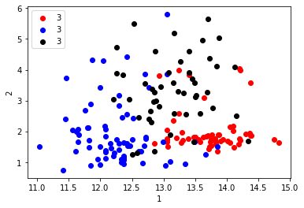

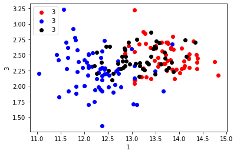

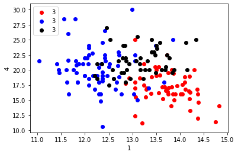

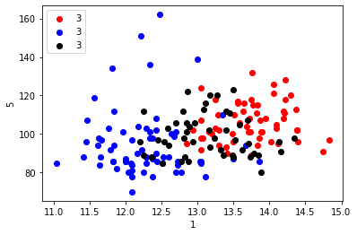

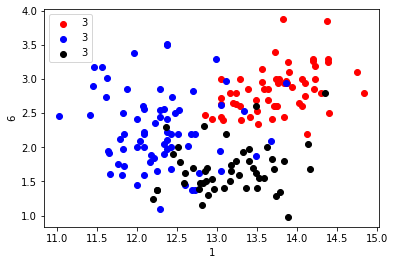

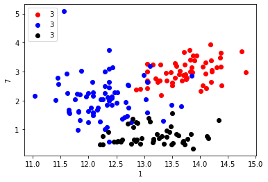

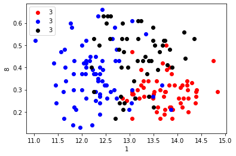

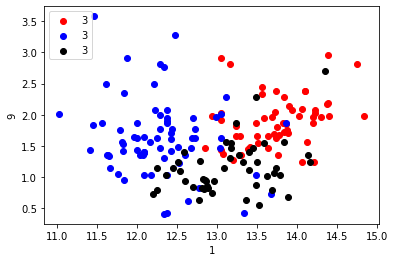

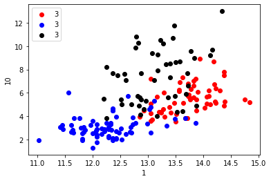

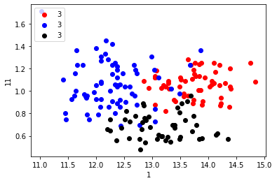

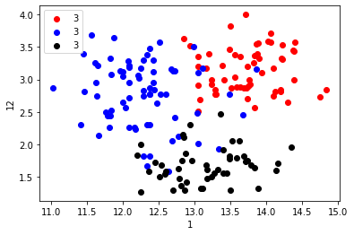

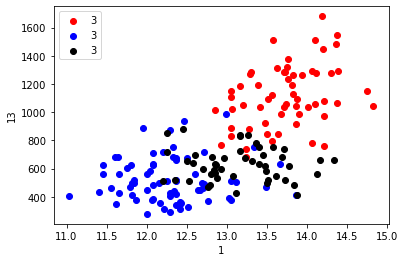

[66 more figures not shown]

```python
for i in range(1, 14):
    j = i + 1
    for k in range(13):
        if j >= 14:
            break
        Plot2([i, j], df)
        j = j + 1
```

### 分類訓練集、測試集

> 經過觀察[1, 6]、[1, 7]、[1, 11]、[1、12]、[11、13]都滿符合條件的 最後選擇 **[11、13]** 作為我們取的input X  
> 由於最小測資只有48筆(接近上一題的50筆)，測試集每種類抽15筆出來，**共45筆**

```python
X_train_list = []
Y_train_list = []
X_test_list = []
Y_test_list = []
j = 0
for i in classdata_list:
    X_train_list.append(i.iloc[15:, [11, 13]].values)
    temp = i.iloc[15:, [11,13]].values.shape
    Y_train_list.append(np.full(temp[0], j))
    X_test_list.append(i.iloc[:15, [11, 13]].values)
    Y_test_list.append(np.full(15,j))
    j = j + 1
X_train_list = np.vstack(X_train_list)
X_test_list = np.vstack(X_test_list)
Y_train_list = np.hstack(Y_train_list)
Y_test_list = np.hstack(Y_test_list)
X_train_list = Std(X_train_list, 2)
X_test_list = Std(X_test_list, 2)
```

# Result

## 訓練、測試模型

```python
mppn = OvR(eta = 0.01, n_iter=400, algo = 'Perceptron')
mppn.fit(X_train_list, Y_train_list)
pre_list = mppn.predict(X_test_list)
print(Y_test_list.tolist())
print(pre_list)
print('acc = ', ACC(pre_list, Y_test_list.tolist()))
```

```
[0, 0, 0, 0, 0, 0, 0, 0, 0, 0, 0, 0, 0, 0, 0, 1, 1, 1, 1, 1, 1, 1, 1, 1, 1, 1, 1, 1, 1, 1, 2, 2, 2, 2, 2, 2, 2, 2, 2, 2, 2, 2, 2, 2, 2]
[0, 0, 2, 1, 0, 0, 0, 0, 2, 0, 0, 0, 1, 0, 1, 1, 1, 1, 1, 1, 1, 1, 1, 1, 1, 1, 2, 1, 1, 1, 2, 2, 2, 2, 2, 2, 2, 2, 2, 2, 2, 2, 2, 2, 2]
acc =  0.8666666666666667
```

```python
mada = OvR(eta = 0.01, n_iter=30, algo = 'Adaline')
mada.fit(X_train_list, Y_train_list)
pre_list = mada.predict(X_test_list)
print(Y_test_list.tolist())
print(pre_list)
print('acc = ', ACC(pre_list, Y_test_list.tolist()))
```

```
[0, 0, 0, 0, 0, 0, 0, 0, 0, 0, 0, 0, 0, 0, 0, 1, 1, 1, 1, 1, 1, 1, 1, 1, 1, 1, 1, 1, 1, 1, 2, 2, 2, 2, 2, 2, 2, 2, 2, 2, 2, 2, 2, 2, 2]
[0, 0, 0, 1, 0, 0, 0, 0, 0, 0, 0, 0, 0, 0, 0, 1, 1, 1, 1, 1, 1, 1, 1, 1, 1, 1, 2, 1, 1, 0, 2, 2, 2, 2, 2, 2, 2, 2, 2, 1, 2, 2, 1, 1, 2]
acc =  0.8666666666666667
```

```python
mada = OvR(eta = 0.02, n_iter=25, algo = 'AdalineSGD')
mada.fit(X_train_list, Y_train_list)
pre_list = mada.predict(X_test_list)
print(Y_test_list.tolist())
print(pre_list)
print('acc = ', ACC(pre_list, Y_test_list.tolist()))
```

```
[0, 0, 0, 0, 0, 0, 0, 0, 0, 0, 0, 0, 0, 0, 0, 1, 1, 1, 1, 1, 1, 1, 1, 1, 1, 1, 1, 1, 1, 1, 2, 2, 2, 2, 2, 2, 2, 2, 2, 2, 2, 2, 2, 2, 2]
[0, 0, 0, 1, 0, 0, 0, 0, 0, 0, 0, 0, 0, 0, 0, 1, 1, 1, 1, 1, 1, 1, 1, 1, 1, 1, 2, 1, 1, 1, 2, 2, 2, 2, 2, 2, 2, 2, 2, 1, 2, 2, 1, 1, 2]
acc =  0.8888888888888888
```

### 最高準確率：88.9%

# Discuss

> 關於資料分析：一開始看到feature那麼多有點驚慌失措，但是把圖plot出來後就把不重要的feature過濾掉了  
> 關於Training : 這次在tune參數的時候，SGD、ADA 跟 PPN的差別就很明顯，PPN要到400個epoch才能夠train好  
> ADA 跟 SGD就少很多，因為資料量少，所以一開始還是採取用時間換取準確率的方式，這次準確率最高有到88%，比上一題高  
> 滿有成就感的

# Concusion

> 這次作業主要讓我了解到兩件事：
> 1. **線性模型有它的限制，相關性高的特徵效果不好**：一開始想很久原因，不知道為甚麼肉眼看很好分的線，train出來那麼爛  
>    把predict印出來後發現中間內一類全壞掉，才推測了解原因，推出來後滿有成就感的，也讓後面那一題很好處理
> 2. **learning rate調太大會結果壞掉** : 一開始learning rate沒調好，結果一直滿差的，後來把lr rate放小，n_iter放大，  
>    才慢慢把準確率拉高，透過實作確實了解這件事 以上，這次作業收穫很多，第一次把課程理論應用到實際問題，還有第二題自己解決分析測資並得到高準確率滿開心的